# Part I - Communicate Data finding (load prosper dataset)

## Preliminary Wrangling

```python
# import all packages and set plots to be embedded inline
import numpy as np
import pandas as pd
import matplotlib.pyplot as plt
import seaborn as sb
import warnings
warnings.filterwarnings('ignore')
%matplotlib inline

# Show the full results
pd.set_option('display.max_column', None)
pd.set_option('display.max_rows', None)

base_color = sb.color_palette()[0]
```

> Load in your dataset and describe its properties through the questions below. Try and motivate your exploration goals through this section.

```python
df = pd.read_csv('Data/prosperLoanData.csv')
df.head()
```

|  | ListingKey | ListingNumber | ListingCreationDate | CreditGrade | Term | LoanStatus | ClosedDate | BorrowerAPR | BorrowerRate | LenderYield | EstimatedEffectiveYield | EstimatedLoss | EstimatedReturn | ProsperRating (numeric) | ProsperRating (Alpha) | ProsperScore | ListingCategory (numeric) | BorrowerState | Occupation | EmploymentStatus | EmploymentStatusDuration | IsBorrowerHomeowner | CurrentlyInGroup | GroupKey | DateCreditPulled | CreditScoreRangeLower | CreditScoreRangeUpper | FirstRecordedCreditLine | CurrentCreditLines | … |
| --- | --- | --- | --- | --- | --- | --- | --- | --- | --- | --- | --- | --- | --- | --- | --- | --- | --- | --- | --- | --- | --- | --- | --- | --- | --- | --- | --- | --- | --- | --- |
| 0 | 1021339766868145413AB3B | 193129 | 2007-08-26 19:09:29.263000000 | C | 36 | Completed | 2009-08-14 00:00:00 | 0.16516 | 0.1580 | 0.1380 | NaN | NaN | NaN | NaN | NaN | NaN | 0 | CO | Other | Self-employed | 2.0 | True | True | NaN | 2007-08-26 18:41:46.780000000 | 640.0 | 659.0 | 2001-10-11 00:00:00 | 5.0 | … |
| 1 | 10273602499503308B223C1 | 1209647 | 2014-02-27 08:28:07.900000000 | NaN | 36 | Current | NaN | 0.12016 | 0.0920 | 0.0820 | 0.07960 | 0.0249 | 0.05470 | 6.0 | A | 7.0 | 2 | CO | Professional | Employed | 44.0 | False | False | NaN | 2014-02-27 08:28:14 | 680.0 | 699.0 | 1996-03-18 00:00:00 | 14.0 | … |
| 2 | 0EE9337825851032864889A | 81716 | 2007-01-05 15:00:47.090000000 | HR | 36 | Completed | 2009-12-17 00:00:00 | 0.28269 | 0.2750 | 0.2400 | NaN | NaN | NaN | NaN | NaN | NaN | 0 | GA | Other | Not available | NaN | False | True | 783C3371218786870A73D20 | 2007-01-02 14:09:10.060000000 | 480.0 | 499.0 | 2002-07-27 00:00:00 | NaN | … |
| 3 | 0EF5356002482715299901A | 658116 | 2012-10-22 11:02:35.010000000 | NaN | 36 | Current | NaN | 0.12528 | 0.0974 | 0.0874 | 0.08490 | 0.0249 | 0.06000 | 6.0 | A | 9.0 | 16 | GA | Skilled Labor | Employed | 113.0 | True | False | NaN | 2012-10-22 11:02:32 | 800.0 | 819.0 | 1983-02-28 00:00:00 | 5.0 | … |
| 4 | 0F023589499656230C5E3E2 | 909464 | 2013-09-14 18:38:39.097000000 | NaN | 36 | Current | NaN | 0.24614 | 0.2085 | 0.1985 | 0.18316 | 0.0925 | 0.09066 | 3.0 | D | 4.0 | 2 | MN | Executive | Employed | 44.0 | True | False | NaN | 2013-09-14 18:38:44 | 680.0 | 699.0 | 2004-02-20 00:00:00 | 19.0 | … |

```python
# What is the structure of your dataset?
df.shape
```

```
(113937, 81)
```

```python
### What is/are the main feature(s) of interest in your dataset?
df.info()
```

```
<class 'pandas.core.frame.DataFrame'>
RangeIndex: 113937 entries, 0 to 113936
Data columns (total 81 columns):
 #   Column                               Non-Null Count   Dtype
---  ------                               --------------   -----
 0   ListingKey                           113937 non-null  object
 1   ListingNumber                        113937 non-null  int64
 2   ListingCreationDate                  113937 non-null  object
 3   CreditGrade                          28953 non-null   object
 4   Term                                 113937 non-null  int64
 5   LoanStatus                           113937 non-null  object
 6   ClosedDate                           55089 non-null   object
 7   BorrowerAPR                          113912 non-null  float64
 8   BorrowerRate                         113937 non-null  float64
 9   LenderYield                          113937 non-null  float64
```

[output cut: 73 more lines]

###### What is the structure of your dataset?

There are 113937 instances in the dataset with 81 variables.

##### What is/are the main feature(s) of interest in your dataset?

The main features are ProsperRating, occupation and employment state

##### What features in the dataset do you think will help support your investigation into your feature(s) of interest?

Though there are many features to explore, I suspect the following borrower features will have the largest effect on the performance of the loan:

IncomeRange DebToIncomeRatio CreditGrade ProsperRating EmploymentStatus

```python
loan = df.copy()
```

###### Selecting Important features According to the dictionary list of features

```python
cols = ['CreditGrade', 'LoanOriginalAmount','LoanStatus','ListingCategory (numeric)',
        'BorrowerAPR','BorrowerRate','StatedMonthlyIncome', 'ProsperScore', 'Occupation',
        'IsBorrowerHomeowner', 'Term','EmploymentStatus', 'TotalInquiries','DebtToIncomeRatio','MonthlyLoanPayment',
        'TotalTrades','Investors', 'AvailableBankcardCredit', 'CreditScoreRangeLower', 'CreditScoreRangeUpper']
```

```python
loan = loan[cols]
```

```python
loan.head()
```

|  | CreditGrade | LoanOriginalAmount | LoanStatus | ListingCategory (numeric) | BorrowerAPR | BorrowerRate | StatedMonthlyIncome | ProsperScore | Occupation | IsBorrowerHomeowner | Term | EmploymentStatus | TotalInquiries | DebtToIncomeRatio | MonthlyLoanPayment | TotalTrades | Investors | AvailableBankcardCredit | CreditScoreRangeLower | CreditScoreRangeUpper |
| --- | --- | --- | --- | --- | --- | --- | --- | --- | --- | --- | --- | --- | --- | --- | --- | --- | --- | --- | --- | --- |
| 0 | C | 9425 | Completed | 0 | 0.16516 | 0.1580 | 3083.333333 | NaN | Other | True | 36 | Self-employed | 3.0 | 0.17 | 330.43 | 11.0 | 258 | 1500.0 | 640.0 | 659.0 |
| 1 | NaN | 10000 | Current | 2 | 0.12016 | 0.0920 | 6125.000000 | 7.0 | Professional | False | 36 | Employed | 5.0 | 0.18 | 318.93 | 29.0 | 1 | 10266.0 | 680.0 | 699.0 |
| 2 | HR | 3001 | Completed | 0 | 0.28269 | 0.2750 | 2083.333333 | NaN | Other | False | 36 | Not available | 1.0 | 0.06 | 123.32 | NaN | 41 | NaN | 480.0 | 499.0 |
| 3 | NaN | 10000 | Current | 16 | 0.12528 | 0.0974 | 2875.000000 | 9.0 | Skilled Labor | True | 36 | Employed | 1.0 | 0.15 | 321.45 | 26.0 | 158 | 30754.0 | 800.0 | 819.0 |
| 4 | NaN | 15000 | Current | 2 | 0.24614 | 0.2085 | 9583.333333 | 4.0 | Executive | True | 36 | Employed | 9.0 | 0.26 | 563.97 | 39.0 | 20 | 695.0 | 680.0 | 699.0 |

```python
loan.shape
```

```
(113937, 20)
```

###### Remove highly null rows or columns

```python
percentCol = loan.isnull().sum()/loan.shape[0]
percentCol
```

```
CreditGrade                  0.745886
LoanOriginalAmount           0.000000
LoanStatus                   0.000000
ListingCategory (numeric)    0.000000
BorrowerAPR                  0.000219
BorrowerRate                 0.000000
StatedMonthlyIncome          0.000000
ProsperScore                 0.255264
Occupation                   0.031491
IsBorrowerHomeowner          0.000000
Term                         0.000000
EmploymentStatus             0.019792
TotalInquiries               0.010172
DebtToIncomeRatio            0.075077
MonthlyLoanPayment           0.000000
TotalTrades                  0.066212
Investors                    0.000000
AvailableBankcardCredit      0.066212
CreditScoreRangeLower        0.005187
CreditScoreRangeUpper        0.005187
dtype: float64
```

```python
dropCol = percentCol[percentCol>0.3].index
```

```python
# Drop columns that have over 30 %
loan.drop(dropCol, axis =1, inplace = True)
```

```python
sum(loan.duplicated())
```

```
0
```

```python
# Drop duplicates
loan = loan.drop_duplicates(keep='last')
loan.shape
```

```
(113937, 19)
```

```python
loan[['ProsperScore']].head()
```

|  | ProsperScore |
| --- | --- |
| 0 | NaN |
| 1 | 7.0 |
| 2 | NaN |
| 3 | 9.0 |
| 4 | 4.0 |

```python
loan.info()
```

```
<class 'pandas.core.frame.DataFrame'>
Int64Index: 113937 entries, 0 to 113936
Data columns (total 19 columns):
 #   Column                     Non-Null Count   Dtype
---  ------                     --------------   -----
 0   LoanOriginalAmount         113937 non-null  int64
 1   LoanStatus                 113937 non-null  object
 2   ListingCategory (numeric)  113937 non-null  int64
 3   BorrowerAPR                113912 non-null  float64
 4   BorrowerRate               113937 non-null  float64
 5   StatedMonthlyIncome        113937 non-null  float64
 6   ProsperScore               84853 non-null   float64
 7   Occupation                 110349 non-null  object
 8   IsBorrowerHomeowner        113937 non-null  bool
 9   Term                       113937 non-null  int64
 10  EmploymentStatus           111682 non-null  object
 11  TotalInquiries             112778 non-null  float64
 12  DebtToIncomeRatio          105383 non-null  float64
 13  MonthlyLoanPayment         113937 non-null  float64
 14  TotalTrades                106393 non-null  float64
 15  Investors                  113937 non-null  int64
 16  AvailableBankcardCredit    106393 non-null  float64
 17  CreditScoreRangeLower      113346 non-null  float64
 18  CreditScoreRangeUpper      113346 non-null  float64
dtypes: bool(1), float64(11), int64(4), object(3)
memory usage: 16.6+ MB
```

```python
loan = loan[loan.ProsperScore.notnull()]
```

```python
loan.shape
```

```
(84853, 19)
```

```python
loan.head()
```

|  | LoanOriginalAmount | LoanStatus | ListingCategory (numeric) | BorrowerAPR | BorrowerRate | StatedMonthlyIncome | ProsperScore | Occupation | IsBorrowerHomeowner | Term | EmploymentStatus | TotalInquiries | DebtToIncomeRatio | MonthlyLoanPayment | TotalTrades | Investors | AvailableBankcardCredit | CreditScoreRangeLower | CreditScoreRangeUpper |
| --- | --- | --- | --- | --- | --- | --- | --- | --- | --- | --- | --- | --- | --- | --- | --- | --- | --- | --- | --- |
| 1 | 10000 | Current | 2 | 0.12016 | 0.0920 | 6125.000000 | 7.0 | Professional | False | 36 | Employed | 5.0 | 0.18 | 318.93 | 29.0 | 1 | 10266.0 | 680.0 | 699.0 |
| 3 | 10000 | Current | 16 | 0.12528 | 0.0974 | 2875.000000 | 9.0 | Skilled Labor | True | 36 | Employed | 1.0 | 0.15 | 321.45 | 26.0 | 158 | 30754.0 | 800.0 | 819.0 |
| 4 | 15000 | Current | 2 | 0.24614 | 0.2085 | 9583.333333 | 4.0 | Executive | True | 36 | Employed | 9.0 | 0.26 | 563.97 | 39.0 | 20 | 695.0 | 680.0 | 699.0 |
| 5 | 15000 | Current | 1 | 0.15425 | 0.1314 | 8333.333333 | 10.0 | Professional | True | 60 | Employed | 2.0 | 0.36 | 342.37 | 47.0 | 1 | 86509.0 | 740.0 | 759.0 |
| 6 | 3000 | Current | 1 | 0.31032 | 0.2712 | 2083.333333 | 2.0 | Sales - Retail | False | 36 | Employed | 0.0 | 0.27 | 122.67 | 16.0 | 1 | 1929.0 | 680.0 | 699.0 |

```python
loan.isnull().sum()
```

```
LoanOriginalAmount              0
LoanStatus                      0
ListingCategory (numeric)       0
BorrowerAPR                     0
BorrowerRate                    0
StatedMonthlyIncome             0
ProsperScore                    0
Occupation                   1333
IsBorrowerHomeowner             0
Term                            0
EmploymentStatus                0
TotalInquiries                  0
DebtToIncomeRatio            7296
MonthlyLoanPayment              0
TotalTrades                     0
Investors                       0
AvailableBankcardCredit         0
CreditScoreRangeLower           0
CreditScoreRangeUpper           0
dtype: int64
```

```python
loan[loan.Occupation.isnull()].head()
```

|  | LoanOriginalAmount | LoanStatus | ListingCategory (numeric) | BorrowerAPR | BorrowerRate | StatedMonthlyIncome | ProsperScore | Occupation | IsBorrowerHomeowner | Term | EmploymentStatus | TotalInquiries | DebtToIncomeRatio | MonthlyLoanPayment | TotalTrades | Investors | AvailableBankcardCredit | CreditScoreRangeLower | CreditScoreRangeUpper |
| --- | --- | --- | --- | --- | --- | --- | --- | --- | --- | --- | --- | --- | --- | --- | --- | --- | --- | --- | --- |
| 34 | 10000 | Current | 1 | 0.22966 | 0.1920 | 4058.333333 | 5.0 | NaN | True | 36 | Other | 5.0 | 0.17 | 367.57 | 14.0 | 1 | 266.0 | 640.0 | 659.0 |
| 161 | 4000 | Current | 1 | 0.17151 | 0.1355 | 2429.166667 | 4.0 | NaN | True | 36 | Other | 2.0 | 0.15 | 135.84 | 22.0 | 2 | 1284.0 | 680.0 | 699.0 |
| 229 | 4000 | Current | 1 | 0.22773 | 0.1905 | 1250.000000 | 4.0 | NaN | False | 36 | Other | 0.0 | 0.39 | 146.73 | 7.0 | 1 | 751.0 | 700.0 | 719.0 |
| 237 | 4000 | Current | 1 | 0.19859 | 0.1620 | 2166.666667 | 3.0 | NaN | False | 36 | Other | 5.0 | 0.35 | 141.02 | 25.0 | 1 | 1006.0 | 700.0 | 719.0 |
| 349 | 4000 | Current | 1 | 0.17090 | 0.1349 | 2000.000000 | 5.0 | NaN | False | 36 | Other | 0.0 | 0.14 | 135.72 | 8.0 | 1 | 3600.0 | 760.0 | 779.0 |

```python
loan.Occupation.value_counts()
```

```
Other                                 21317
Professional                          10542
Executive                              3468
Computer Programmer                    3236
Teacher                                2888
Analyst                                2735
Administrative Assistant               2708
Accountant/CPA                         2574
Sales - Commission                     2350
Skilled Labor                          2180
Nurse (RN)                             2159
Clerical                               2116
Sales - Retail                         2029
Retail Management                      2001
Truck Driver                           1366
Construction                           1326
Police Officer/Correction Officer      1277
Laborer                                1217
Civil Service                          1139
Engineer - Mechanical                  1135
Food Service Management                1005
Engineer - Electrical                   900
Medical Technician                      891
Attorney                                866
Food Service                            837
Military Enlisted                       824
Tradesman - Mechanic                    797
Social Worker                           575
Postal Service                          487
Professor                               452
Nurse (LPN)                             416
Doctor                                  393
Tradesman - Electrician                 385
Nurse's Aide                            382
Fireman                                 319
Waiter/Waitress                         294
Scientist                               292
Principal                               262
Realtor                                 252
Military Officer                        252
```

[output cut: 13 more lines]

```
Biologist                                95
Religious                                93
Flight Attendant                         87
Tradesman - Carpenter                    85
Tradesman - Plumber                      74
Student - College Senior                 70
Homemaker                                57
Dentist                                  56
Student - College Junior                 27
Judge                                    22
Student - College Freshman               17
Student - College Sophomore              16
Student - Community College              10
Student - Technical School                2
Name: Occupation, dtype: int64
```

```python
loan['DebtToIncomeRatio'].fillna(loan['DebtToIncomeRatio'].mean(), inplace = True)
loan['Occupation'].fillna('Other', inplace = True)
```

```python
loan.Occupation.value_counts()
```

```
Other                                 22650
Professional                          10542
Executive                              3468
Computer Programmer                    3236
Teacher                                2888
Analyst                                2735
Administrative Assistant               2708
Accountant/CPA                         2574
Sales - Commission                     2350
Skilled Labor                          2180
Nurse (RN)                             2159
Clerical                               2116
Sales - Retail                         2029
Retail Management                      2001
Truck Driver                           1366
Construction                           1326
Police Officer/Correction Officer      1277
Laborer                                1217
Civil Service                          1139
Engineer - Mechanical                  1135
Food Service Management                1005
Engineer - Electrical                   900
Medical Technician                      891
Attorney                                866
Food Service                            837
Military Enlisted                       824
Tradesman - Mechanic                    797
Social Worker                           575
Postal Service                          487
Professor                               452
Nurse (LPN)                             416
Doctor                                  393
Tradesman - Electrician                 385
Nurse's Aide                            382
Fireman                                 319
Waiter/Waitress                         294
Scientist                               292
Principal                               262
Realtor                                 252
Military Officer                        252
```

[output cut: 13 more lines]

```
Biologist                                95
Religious                                93
Flight Attendant                         87
Tradesman - Carpenter                    85
Tradesman - Plumber                      74
Student - College Senior                 70
Homemaker                                57
Dentist                                  56
Student - College Junior                 27
Judge                                    22
Student - College Freshman               17
Student - College Sophomore              16
Student - Community College              10
Student - Technical School                2
Name: Occupation, dtype: int64
```

```python
loan.isnull().sum()
```

```
LoanOriginalAmount           0
LoanStatus                   0
ListingCategory (numeric)    0
BorrowerAPR                  0
BorrowerRate                 0
StatedMonthlyIncome          0
ProsperScore                 0
Occupation                   0
IsBorrowerHomeowner          0
Term                         0
EmploymentStatus             0
TotalInquiries               0
DebtToIncomeRatio            0
MonthlyLoanPayment           0
TotalTrades                  0
Investors                    0
AvailableBankcardCredit      0
CreditScoreRangeLower        0
CreditScoreRangeUpper        0
dtype: int64
```

```python
loan['CreditScoreRange'] = loan[['CreditScoreRangeLower', 'CreditScoreRangeUpper']].mean(axis=1)
loan.head()
```

|  | LoanOriginalAmount | LoanStatus | ListingCategory (numeric) | BorrowerAPR | BorrowerRate | StatedMonthlyIncome | ProsperScore | Occupation | IsBorrowerHomeowner | Term | EmploymentStatus | TotalInquiries | DebtToIncomeRatio | MonthlyLoanPayment | TotalTrades | Investors | AvailableBankcardCredit | CreditScoreRangeLower | CreditScoreRangeUpper | CreditScoreRange |
| --- | --- | --- | --- | --- | --- | --- | --- | --- | --- | --- | --- | --- | --- | --- | --- | --- | --- | --- | --- | --- |
| 1 | 10000 | Current | 2 | 0.12016 | 0.0920 | 6125.000000 | 7.0 | Professional | False | 36 | Employed | 5.0 | 0.18 | 318.93 | 29.0 | 1 | 10266.0 | 680.0 | 699.0 | 689.5 |
| 3 | 10000 | Current | 16 | 0.12528 | 0.0974 | 2875.000000 | 9.0 | Skilled Labor | True | 36 | Employed | 1.0 | 0.15 | 321.45 | 26.0 | 158 | 30754.0 | 800.0 | 819.0 | 809.5 |
| 4 | 15000 | Current | 2 | 0.24614 | 0.2085 | 9583.333333 | 4.0 | Executive | True | 36 | Employed | 9.0 | 0.26 | 563.97 | 39.0 | 20 | 695.0 | 680.0 | 699.0 | 689.5 |
| 5 | 15000 | Current | 1 | 0.15425 | 0.1314 | 8333.333333 | 10.0 | Professional | True | 60 | Employed | 2.0 | 0.36 | 342.37 | 47.0 | 1 | 86509.0 | 740.0 | 759.0 | 749.5 |
| 6 | 3000 | Current | 1 | 0.31032 | 0.2712 | 2083.333333 | 2.0 | Sales - Retail | False | 36 | Employed | 0.0 | 0.27 | 122.67 | 16.0 | 1 | 1929.0 | 680.0 | 699.0 | 689.5 |

```python
loan.drop(['CreditScoreRangeLower', 'CreditScoreRangeUpper'], axis = 1, inplace = True)
```

## Univariate Exploration

> In this section, investigate distributions of individual variables. If you see unusual points or outliers, take a deeper look to clean things up and prepare yourself to look at relationships between variables.

```python
loan.head(2)
```

|  | LoanOriginalAmount | LoanStatus | ListingCategory (numeric) | BorrowerAPR | BorrowerRate | StatedMonthlyIncome | ProsperScore | Occupation | IsBorrowerHomeowner | Term | EmploymentStatus | TotalInquiries | DebtToIncomeRatio | MonthlyLoanPayment | TotalTrades | Investors | AvailableBankcardCredit | CreditScoreRange |
| --- | --- | --- | --- | --- | --- | --- | --- | --- | --- | --- | --- | --- | --- | --- | --- | --- | --- | --- |
| 1 | 10000 | Current | 2 | 0.12016 | 0.0920 | 6125.0 | 7.0 | Professional | False | 36 | Employed | 5.0 | 0.18 | 318.93 | 29.0 | 1 | 10266.0 | 689.5 |
| 3 | 10000 | Current | 16 | 0.12528 | 0.0974 | 2875.0 | 9.0 | Skilled Labor | True | 36 | Employed | 1.0 | 0.15 | 321.45 | 26.0 | 158 | 30754.0 | 809.5 |

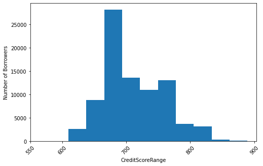

```python
# distribution of DebtToIncomeRatio
plt.figure(figsize=[8, 5])
plt.hist(data = loan, x = 'CreditScoreRange')
plt.xticks([550, 600, 700, 800, 900], rotation = 45)
plt.xlabel('CreditScoreRange')
plt.ylabel('Number of Borrowers')
plt.show();
```

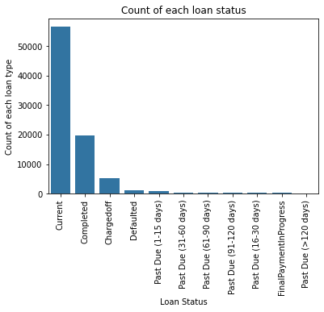

```python
sb.countplot(data = loan, x = 'LoanStatus', color = base_color, order = loan.LoanStatus.value_counts().index)
plt.xlabel('Loan Status')
plt.ylabel('Count of each loan type')
plt.title('Count of each loan status')
plt.xticks(rotation = 90) # Rotates X-Axis Ticks by 45-degrees
plt.show();
```

Most of the loan in the data set are currently running

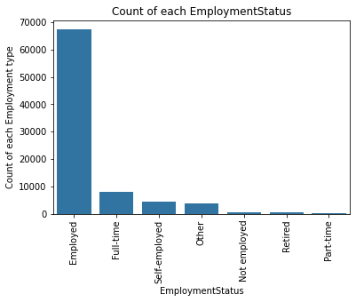

```python
sb.countplot(data = loan, x = 'EmploymentStatus', color = base_color, order = loan.EmploymentStatus.value_counts().index)
plt.xlabel('EmploymentStatus')
plt.ylabel('Count of each Employment type')
plt.title('Count of each EmploymentStatus')
plt.xticks(rotation = 90) # Rotates X-Axis Ticks by 45-degrees
plt.show();
```

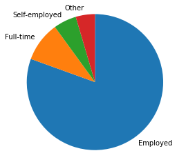

```python
# Use the same pokemon dataset
sorted_counts = loan['EmploymentStatus'].value_counts()[:4]

plt.pie(sorted_counts, labels = sorted_counts.index, startangle = 90, counterclock = False);
plt.axis('square');
```

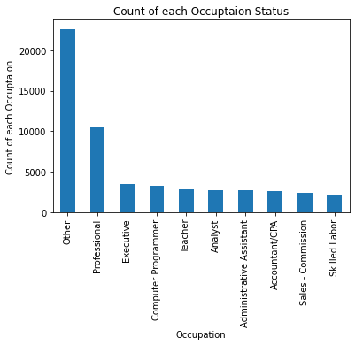

```python
occu_loan = loan.Occupation.value_counts()[:10].plot(kind = 'bar')
plt.xlabel('Occupation')
plt.ylabel('Count of each Occuptaion')
plt.title('Count of each Occuptaion Status')
plt.xticks(rotation = 90) # Rotates X-Axis Ticks by 45-degrees
plt.show();
```

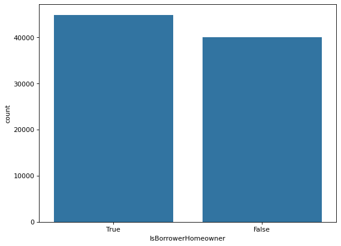

```python
plt.figure(figsize=(8, 6), dpi=80)

sb.countplot(data = loan, x = 'IsBorrowerHomeowner', color = base_color, order = loan.IsBorrowerHomeowner.value_counts().index)
```

The number of borrowers whether own home or not are nearly similar

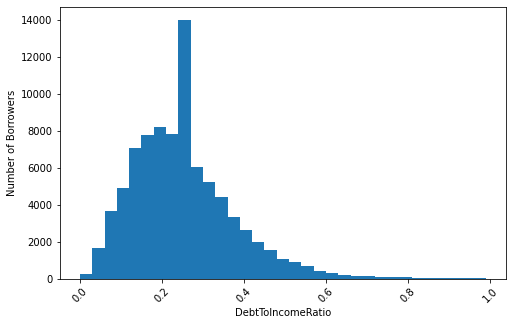

```python
# distribution of DebtToIncomeRatio
bins = np.arange(0,1, 0.03)
plt.figure(figsize=[8, 5])
plt.hist(data = loan, x = 'DebtToIncomeRatio', bins = bins)
plt.xticks([0, 0.2, 0.4, 0.6, 0.8, 1], rotation = 45)
plt.xlabel('DebtToIncomeRatio')
plt.ylabel('Number of Borrowers')
plt.show();
```

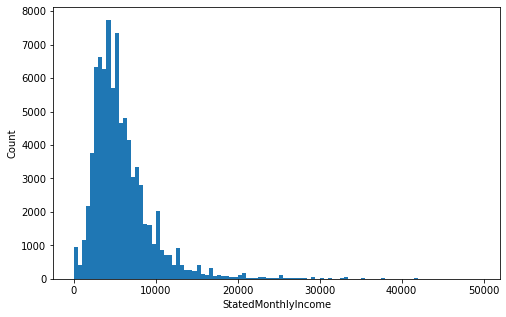

```python
# Distribution of stated monthly income
plt.figure(figsize=[8, 5])
bins_smi = np.arange(0, 50000, 500)
plt.hist(data = loan, x = 'StatedMonthlyIncome', bins=bins_smi)
plt.xlabel('StatedMonthlyIncome')
plt.ylabel('Count')
plt.show();
```

From the previous plot, it is obvious that most of the borrowers have less than 12000 monthly income

### Discuss the distribution(s) of your variable(s) of interest. Were there any unusual points? Did you need to perform any transformations?

From the previous plot, no trasformation is needed

### Of the features you investigated, were there any unusual distributions? Did you perform any operations on the data to tidy, adjust, or change the form of the data? If so, why did you do this?

The debt to income ratio nad the monthly income are right skewed.

The number of the borrower who havbe house is nearly similat to the non owner

## Bivariate Exploration

> In this section, investigate relationships between pairs of variables in your data. Make sure the variables that you cover here have been introduced in some fashion in the previous section (univariate exploration).

```python
loan.columns
```

```
Index(['LoanOriginalAmount', 'LoanStatus', 'ListingCategory (numeric)',
       'BorrowerAPR', 'BorrowerRate', 'StatedMonthlyIncome', 'ProsperScore',
       'Occupation', 'IsBorrowerHomeowner', 'Term', 'EmploymentStatus',
       'TotalInquiries', 'DebtToIncomeRatio', 'MonthlyLoanPayment',
       'TotalTrades', 'Investors', 'AvailableBankcardCredit',
       'CreditScoreRange'],
      dtype='object')
```

```python
numerics = ['int16', 'int32', 'int64','float']
loan_df = loan.select_dtypes(include=numerics)
num_cols = loan_df.columns
```

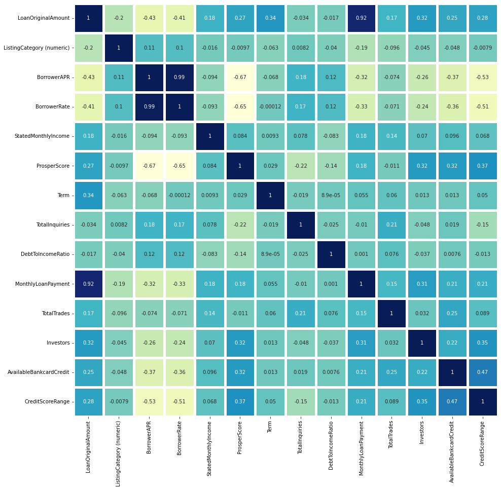

```python
fig, ax = plt.subplots(figsize=(15,15))
sb.heatmap(loan[num_cols].corr(), annot = True, linewidth = 5, cmap="YlGnBu", cbar = False)
plt.title('')
```

From the heatmap:

1. High positive correlation between the loan amount and monthly payment
2. Moderate positive correlation between the availablebank credit card and creditscorerange
3. Moderate -ve correlation between the prosper score and the borooweAPR and rate
4. Moderate -ve correlation between the CreditScoreRange and the borooweAPR and rate
5. Moderate -ve correlation between the Loan original amount and the borrower APR and rate

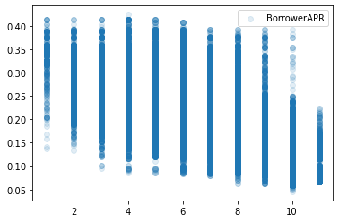

```python
# data setup
fig, ax = plt.subplots()
ax.scatter(data = loan, x = 'ProsperScore', y = 'BorrowerAPR', alpha = 1/8)
ax.legend()
plt.show();
```

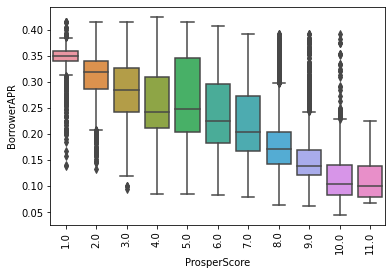

```python
sb.boxplot(data = loan, x = 'ProsperScore', y = 'BorrowerAPR')
plt.xticks(rotation = 90)
plt.show();
```

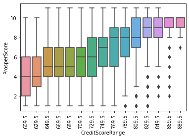

```python
sb.boxplot(data = loan, x = 'CreditScoreRange', y = 'ProsperScore')
plt.xticks(rotation = 90)
plt.show();
```

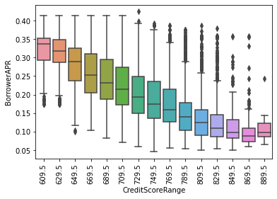

```python
sb.boxplot(data = loan, x = 'CreditScoreRange', y = 'BorrowerAPR')
plt.xticks(rotation = 90)
plt.show();
```

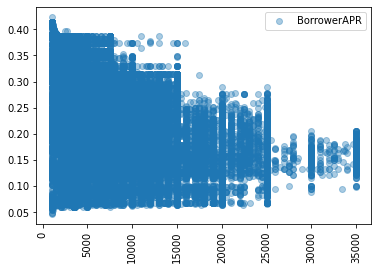

```python
fig, ax = plt.subplots()
ax.scatter(data = loan, x = 'LoanOriginalAmount', y = 'BorrowerAPR', alpha = 3/8)
ax.legend()
plt.xticks(rotation = 90)
plt.show();
```

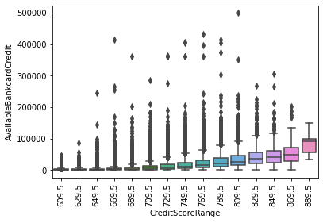

```python
sb.boxplot(data = loan, x = 'CreditScoreRange', y = 'AvailableBankcardCredit')
plt.xticks(rotation = 90)
plt.show();
```

### Talk about some of the relationships you observed in this part of the investigation. How did the feature(s) of interest vary with other features in the dataset?

First of all, the correlation does not mean causation, just a factor to be further investigated using the A/B testing to decide whether a factor affects the final result.

The individuals with high creditscorerange average and available abnk credit have a higher prosperscore.

The borrower APR is negatively correlated with the loan original amount, which mean the more the loan amount, the lower the APR.

### Did you observe any interesting relationships between the other features (not the main feature(s) of interest)?

The credit score and the availabilioty of bank credit have a relation with prosper score and need further investigation

## Multivariate Exploration

> Create plots of three or more variables to investigate your data even further. Make sure that your investigations are justified, and follow from your work in the previous sections.

> I will examine the correlation form the heat map
> 1. High positive correlation between the loan amount and monthly payment
> 2. Moderate positive correlation between the availablebank credit card and creditscorerange
> 3. Moderate -ve correlation between the prosper score and the borooweAPR and rate
> 4. Moderate -ve correlation between the CreditScoreRange and the borooweAPR and rate
> 5. Moderate -ve correlation between the Loan original amount and the borrower APR and rate

```python
loan.columns
```

```
Index(['LoanOriginalAmount', 'LoanStatus', 'ListingCategory (numeric)',
       'BorrowerAPR', 'BorrowerRate', 'StatedMonthlyIncome', 'ProsperScore',
       'Occupation', 'IsBorrowerHomeowner', 'Term', 'EmploymentStatus',
       'TotalInquiries', 'DebtToIncomeRatio', 'MonthlyLoanPayment',
       'TotalTrades', 'Investors', 'AvailableBankcardCredit',
       'CreditScoreRange'],
      dtype='object')
```

[figure not shown]

```python
# Occupation effect on relationship of LoanOriginalAmount and MonthlyLoanPayment
g=sb.FacetGrid(data= loan, aspect=1.2, height=5, col='Occupation', col_wrap=4)
g.map(sb.histplot, 'LoanOriginalAmount', 'MonthlyLoanPayment');
g.add_legend();
```

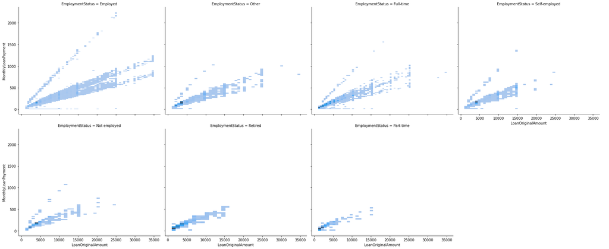

```python
# EmploymentStatus effect on relationship of LoanOriginalAmount and MonthlyLoanPayment
g=sb.FacetGrid(data= loan, aspect=1.2, height=5, col='EmploymentStatus', col_wrap=4)
g.map(sb.histplot, 'LoanOriginalAmount', 'MonthlyLoanPayment');
g.add_legend();
```

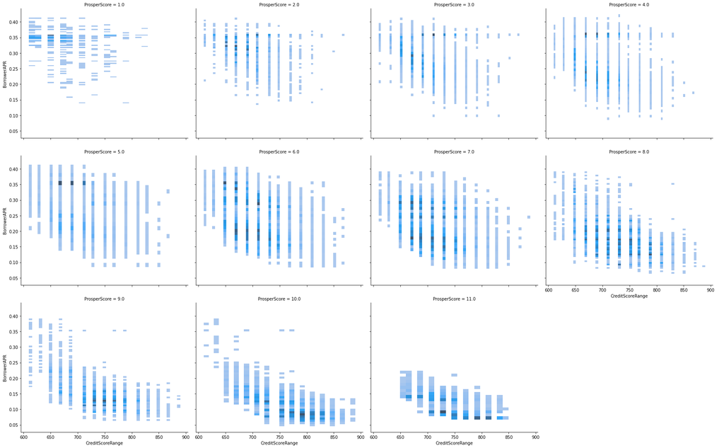

```python
# Prosper score effect on relationship of APR and CreditScoreRange
g=sb.FacetGrid(data=loan, aspect=1.2, height=5, col='ProsperScore', col_wrap=4)
g.map(sb.histplot, 'CreditScoreRange', 'BorrowerAPR');
g.add_legend();
```

[figure not shown]

```python
# Occupation effect on relationship of BorrowerAPR and ProsperScore
g=sb.FacetGrid(data= loan, aspect=1.2, height=5, col='Occupation', col_wrap=4)
g.map(sb.histplot, 'BorrowerAPR', 'ProsperScore');
g.add_legend();
```

### Talk about some of the relationships you observed in this part of the investigation. Were there features that strengthened each other in terms of looking at your feature(s) of interest?

The multivariate visulaization is used to solidify the ideas and insights extracted in the bivariate visualization by inserting a thrid factor into the plot to the if the overall correlation is still valid or not and in my case it is still valid in most of the plots.

### Were there any interesting or surprising interactions between features?

I was not surprised by the result as they are as expected from the heatmap.

## Conclusions

> You can write a summary of the main findings and reflect on the steps taken during the data exploration.
1. High positive correlation between the loan amount and monthly payment
2. Moderate positive correlation between the availablebank credit card and creditscorerange
3. Moderate -ve correlation between the prosper score and the borooweAPR and rate
4. Moderate -ve correlation between the CreditScoreRange and the borooweAPR and rate
5. Moderate -ve correlation between the Loan original amount and the borrower APR and rate

> At the end of your report, make sure that you export the notebook as an html file from the `File > Download as... > HTML or PDF` menu. Make sure you keep track of where the exported file goes, so you can put it in the same folder as this notebook for project submission. Also, make sure you remove all of the quote-formatted guide notes like this one before you finish your report!